# ggplot2

*Основные компоненты графика ggplot*:

- ggplot() - *create a new ggplot*
- data - *data.frame format data*
- aes() - *construct aesthetic mappings*
- *layers*, *scales*, *coords*, *facets*, добавленные с помощью *+*
  - слои *layers*
  - геометрические фигуры *geoms* (points, lines, polygons, etc.)
  - статистические преобразования *stats* (binning and counting)
  - параметры *scales* (colour, shape, size, legend and axes)
  - координаты *coords*
  - группировка *facets*
- ggsave() - *save a ggplot (or other grid object) with sensible defaults*
- qplot() quickplot() - *quick plot*

*geom_col & geom_bar*

*geom_col & geom_bar*

```r
dat <- data.frame(
        time = factor(c("Lunch","Dinner"), levels=c("Lunch","Dinner")),
        total_bill = c(14.89, 17.23))
ggplot(data=dat, aes(x=time, y=total_bill)) + geom_col()
```

*geom_col & geom_bar*

```r
ggplot(data=dat, aes(x=time, y=total_bill)) + geom_col()
```

```r
ggplot(data=dat, aes(x=time, y=total_bill)) + geom_bar(stat="identity")
```

*geom_col*

```r
ggplot() + geom_bar(data=dat, aes(x=time, y=total_bill), stat="identity")
```

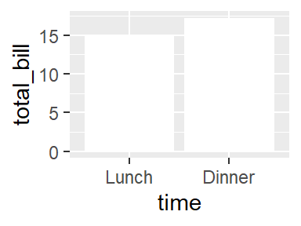

```r
ggplot() + geom_col(data=dat, aes(x=time, y=total_bill), fill = "white")
```

*geom_col*

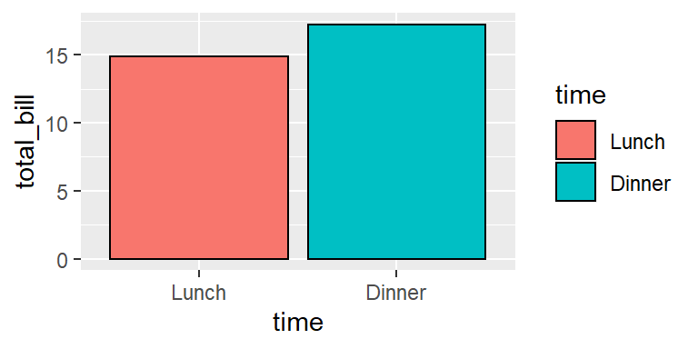

```r
ggplot() +
         geom_col(data=dat,
                  aes(x=time, y=total_bill, fill = time),
                  colour = 'black')
```

*geom_col*

```r
cabbage_exp %>% head(3)
```

```
##   Cultivar Date Weight        sd  n         se
## 1      c39  d16   3.18 0.9566144 10 0.30250803
## 2      c39  d20   2.80 0.2788867 10 0.08819171
## 3      c39  d21   2.74 0.9834181 10 0.31098410
```

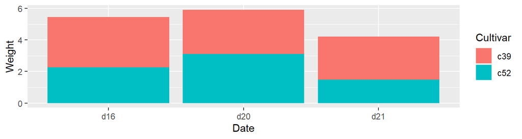

```r
ggplot(cabbage_exp, aes(x = Date, y = Weight, fill = Cultivar)) +
        geom_col()
```

*geom_col*

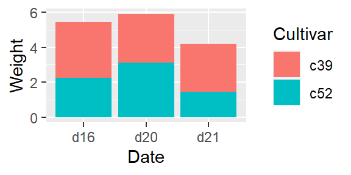

```r
ggplot(cabbage_exp, aes(x = Date, y = Weight, fill = Cultivar)) +
        geom_col()
```

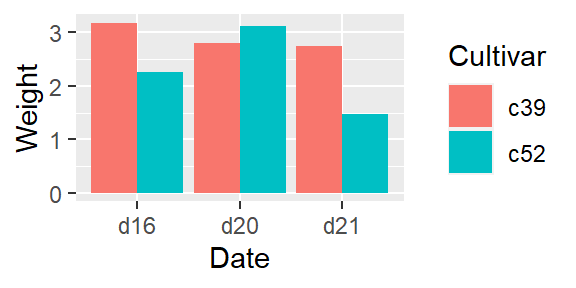

```r
ggplot(cabbage_exp, aes(x = Date, y = Weight, fill = Cultivar)) +
        geom_col(position = "dodge")
```

*geom_bar*

```r
tips %>% head(3)
```

```
##   total_bill  tip    sex smoker day   time size
## 1      16.99 1.01 Female     No Sun Dinner    2
## 2      10.34 1.66   Male     No Sun Dinner    3
## 3      21.01 3.50   Male     No Sun Dinner    3
```

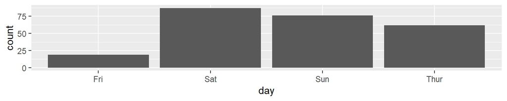

```r
ggplot(data=tips, aes(x=day)) + geom_bar()
```

*geom_boxplot*

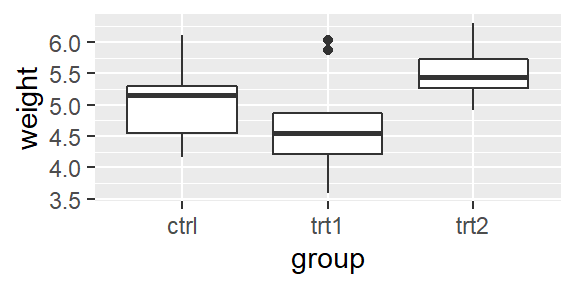

```r
ggplot(PlantGrowth, aes(x=group, y=weight)) +
        geom_boxplot()
```

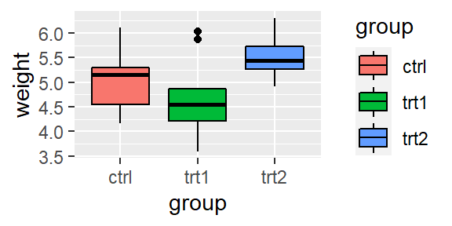

```r
ggplot(PlantGrowth, aes(x=group, y=weight, fill = group)) +
        geom_boxplot(colour="black")
```

*geom_path vs geom_line*

- geom_path() - значения соединены в том порядке, в котором они представлены в df
- geom_line() - значения соединены в том порядке, в котором они представлены по оси x

*geom_path vs geom_line*

```
## # A tibble: 3 x 6
##   date         pce    pop psavert uempmed unemploy
##   <date>     <dbl>  <dbl>   <dbl>   <dbl>    <dbl>
## 1 1967-07-01  507. 198712    12.6     4.5     2944
## 2 1967-08-01  510. 198911    12.6     4.7     2945
## 3 1967-09-01  516. 199113    11.9     4.6     2958
```

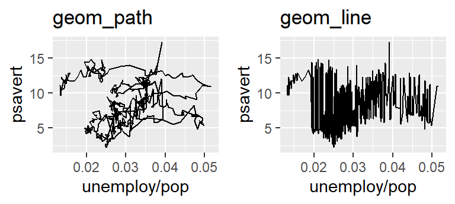

```r
m <- ggplot(economics, aes(unemploy/pop, psavert))
m1 <- m + geom_path()
m2 <- m + geom_line()
```

*geom_line vs geom_step*

```r
recent %>% head(3)
```

```
## # A tibble: 3 x 6
##   date          pce     pop psavert uempmed unemploy
##   <date>      <dbl>   <dbl>   <dbl>   <dbl>    <dbl>
## 1 2013-02-01 11240. 315520.     5.8    17.2    11950
## 2 2013-03-01 11227. 315662.     5.9    17.6    11689
## 3 2013-04-01 11205. 315818.     6.4    17.1    11760
```

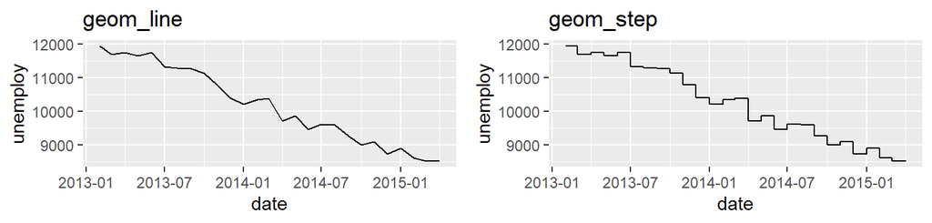

```r
g1 <- ggplot(recent, aes(date, unemploy)) + geom_line()
g2 <- ggplot(recent, aes(date, unemploy)) + geom_step()
```

*geom_line*

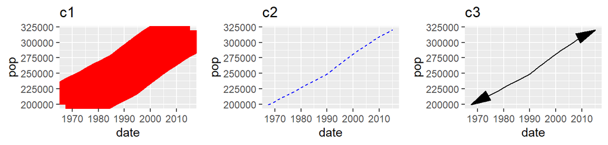

```r
c <- ggplot(economics, aes(x = date, y = pop))
c1 <- c + geom_line(colour = 'red', size = 20)
c2 <- c + geom_line(colour = 'blue', linetype = 2)
c3 <- c + geom_line(arrow = arrow(angle = 15, ends = "both", type = "closed"))
```

*geom_line*

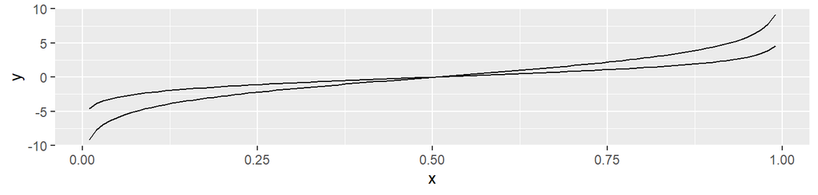

```r
x <- seq(0.01, .99, length.out = 100)
df <- data.frame(
  x = rep(x, 2),
  y = c(qlogis(x), 2 * qlogis(x)),
  group = rep(c("a","b"), each = 100)
)
ggplot(df, aes(x=x, y=y, group=group, fill=group)) + geom_line()
```

*geom_line + geom_point*

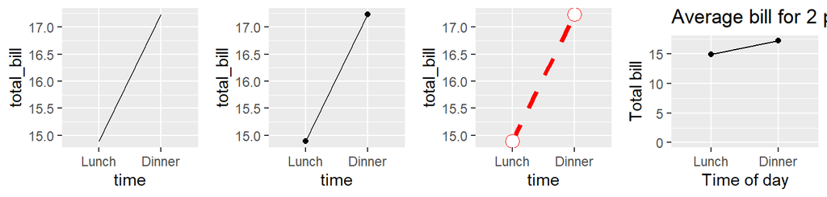

```r
g <- ggplot(data=dat, aes(x=time, y=total_bill, group=1))
gg1 <- g + geom_line()
gg2 <- g + geom_line() + geom_point()
gg3 <- g + geom_line(colour="red", linetype="dashed", size=1.5) +
  geom_point(colour="red", size=4, shape=21, fill="white")
gg4 <- g + geom_line() + geom_point() +
        expand_limits(y=0) +
        xlab("Time of day") + ylab("Total bill") +
        ggtitle("Average bill for 2 people")
```

*geom_histogram, geom_density*

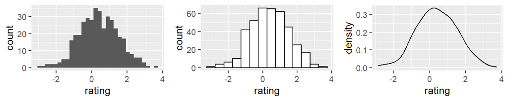

```r
g <- ggplot(dat, aes(x=rating))
gg1 <- g + geom_histogram()
gg2 <- g + geom_histogram(binwidth=.5, colour="black", fill="white")
gg3 <- g + geom_density()
```

*geom_histogram, geom_density*

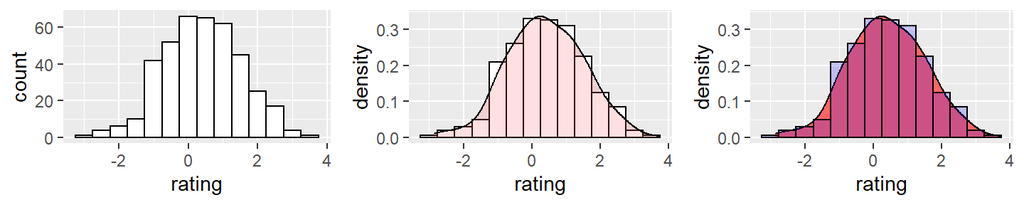

```r
gg4 <- ggplot(dat, aes(x=rating)) +
        geom_density(alpha=.2, fill="#FF6666") +
        geom_histogram(binwidth=.5, colour="black", fill="white")
gg5 <- ggplot(dat, aes(x=rating)) +
        geom_histogram(aes(y=..density..), binwidth=.5,
                       colour="black", fill="white") +
        geom_density(alpha=.2, fill="#FF6666")
gg6 <- ggplot(dat, aes(x=rating)) +
        geom_density(fill="#FF6666") +
        geom_histogram(aes(y=..density..), alpha=.2,  binwidth=.5,
                       colour="black", fill="blue")
```

*geom_errorbar vs geom_pointrang*

```
## # A tibble: 3 x 5
##   supp   dose len_mean len_max len_min
##   <fct> <dbl>    <dbl>   <dbl>   <dbl>
## 1 OJ      0.5     13.2    16.0    10.5
## 2 OJ      1       22.7    25.1    20.3
## 3 OJ      2       26.1    27.7    24.4
```

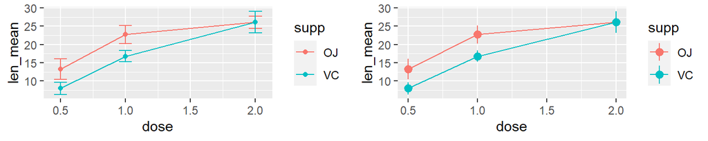

```r
g <- ggplot(tgs, aes(x=dose, y=len_mean, colour=supp))
gg1 <- g + geom_line() + geom_point() +
        geom_errorbar(aes(ymin=len_min, ymax=len_max), width=.1)
gg2 <- g + geom_line() +
         geom_pointrange(aes(ymin=len_min, ymax=len_max))
```

*geom_errorbar*

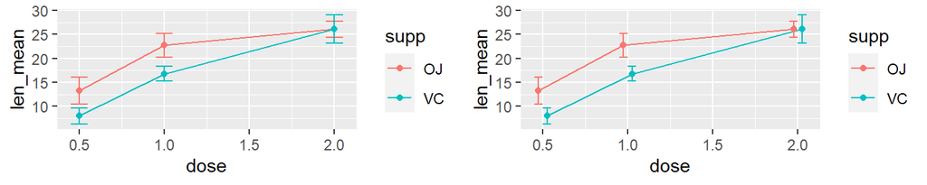

```r
gg1 <- ggplot(tgs, aes(x=dose, y=len_mean, colour=supp)) +
        geom_errorbar(aes(ymin=len_min, ymax=len_max), width=.1) + geom_line() + geom_point()
pd <- position_dodge(0.1) # move them .05 to the left and right
gg2 <- ggplot(tgs, aes(x=dose, y=len_mean, colour=supp)) +
        geom_errorbar(aes(ymin=len_min, ymax=len_max), width=.1, position=pd) + geom_line(position=pd) + geom_point(position=pd)
```

## *geom_point + geom_smooth*

```r
head(dat)
```

```
##   cond      xvar      yvar
## 1    A -2.680445 -2.710581
## 2    A  2.108459  3.122432
## 3    A  1.735821  2.681742
## 4    A  1.301907  4.498186
## 5    A  6.252324  6.974105
## 6    A  6.460334  6.341889
```

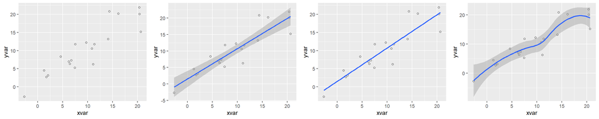

```r
gg1 <- ggplot(dat, aes(x=xvar, y=yvar)) + geom_point(shape=1)
gg2 <- ggplot(dat, aes(x=xvar, y=yvar)) + geom_point(shape=1) + geom_smooth(method=lm) # Add linear regression line (by default includes 95% confidence region)
gg3 <- ggplot(dat, aes(x=xvar, y=yvar)) + geom_point(shape=1) + geom_smooth(method=lm, se=FALSE) # Add linear regression line, don't add shaded confidence region
gg4 <- ggplot(dat, aes(x=xvar, y=yvar)) + geom_point(shape=1) + geom_smooth() # Add a loess smoothed fit curve with confidence region
```

## *geom_text*, *geom_labels*

- label individual observations or groups of observations

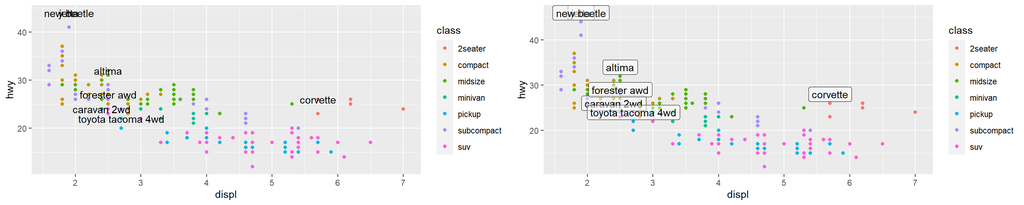

```r
gg1 <- ggplot(mpg, aes(displ, hwy)) +
  geom_point(aes(colour = class)) +
  geom_text(aes(label = model), data = best_in_class)

gg2 <- ggplot(mpg, aes(displ, hwy)) +
  geom_point(aes(colour = class)) +
  geom_label(aes(label = model), data = best_in_class, nudge_y = 2, alpha = 0.5)
```

## *scales*

*scale_[название переменной]_[тип переменной]*

- scale_x_continuous
- scale_y_continuous
- scale_fill_discrete
- scale_colour_discrete
- scale_colour_hue
- scale_fill_manual
- scale_alpha_manual
- scale_shape_manual

## *scales*

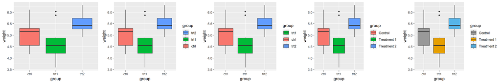

```r
bp <- ggplot(data=PlantGrowth, aes(x=group, y=weight, fill=group)) + geom_boxplot()
bp1 <- bp + scale_fill_discrete(guide=FALSE)
bp2 <- bp + scale_fill_discrete(guide = guide_legend(reverse=TRUE))
bp3 <- bp + scale_fill_discrete(breaks=c("trt1","ctrl","trt2"))
bp4 <- bp + scale_fill_discrete(labels=c("Control", "Treatment 1", "Treatment 2"))
bp5 <- bp + scale_fill_manual(labels=c("Control", "Treatment 1", "Treatment 2"),
                              values=c("#999999", "#E69F00", "#56B4E9"))
```

## *Scales*

```
##      sex   time total_bill
## 1 Female  Lunch      13.53
## 2 Female Dinner      16.81
## 3   Male  Lunch      16.24
## 4   Male Dinner      17.42
```

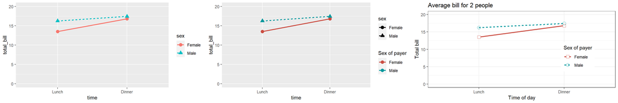

```r
gg <- ggplot(data=dat1, aes(x=time, y=total_bill, group=sex, colour=sex)) + geom_line(aes(linetype=sex), size=1) + geom_point(aes(shape=sex), size=3, fill="white") + expand_limits(y=c(0,20))
gg1 <-  gg + scale_colour_hue(name="Sex of payer", l=50)

gg2 <- gg1 + scale_shape_manual(name="Sex of payer",
                                values=c(22,1)) +
  scale_linetype_discrete(name="Sex of payer") +
  xlab("Time of day") + ylab("Total bill") + # Set axis labels
  ggtitle("Average bill for 2 people") +     # Set title
  theme_bw() +
  theme(legend.position=c(.8, .4))           # Position legend inside
# This must go after theme_bw
```

## *scale*

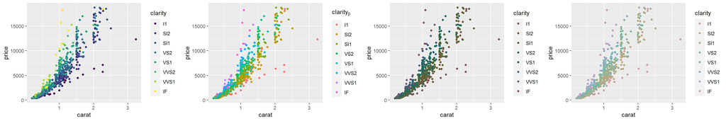

```r
dsamp <- diamonds[sample(nrow(diamonds), 1000), ]
d <- ggplot(dsamp, aes(carat, price)) + geom_point(aes(colour = clarity))
dd1 <- d + scale_colour_hue(expression(clarity[beta]))
dd2 <- d + scale_colour_hue(l = 40, c = 30)
dd3 <- d + scale_colour_hue(l = 70, c = 30)
```

## *scales*

```r
head(mpg)
```

```
## # A tibble: 6 x 11
##   manufacturer model displ  year   cyl trans      drv     cty   hwy fl    class
##   <chr>        <chr> <dbl> <int> <int> <chr>      <chr> <int> <int> <chr> <chr>
## 1 audi         a4      1.8  1999     4 auto(l5)   f        18    29 p     compa~
## 2 audi         a4      1.8  1999     4 manual(m5) f        21    29 p     compa~
## 3 audi         a4      2    2008     4 manual(m6) f        20    31 p     compa~
## 4 audi         a4      2    2008     4 auto(av)   f        21    30 p     compa~
## 5 audi         a4      2.8  1999     6 auto(l5)   f        16    26 p     compa~
## 6 audi         a4      2.8  1999     6 manual(m5) f        18    26 p     compa~
```

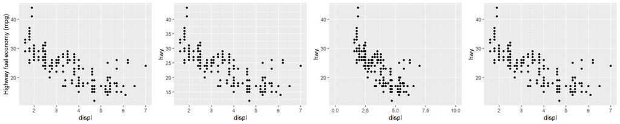

```r
gg <- ggplot(mpg, aes(displ, hwy)) + geom_point()
gg1 <- gg + scale_y_continuous(name = 'Highway fuel economy (mpg)')
gg2 <- gg + scale_y_continuous(breaks = seq(0, 40, by = 5))
gg3 <- gg + scale_x_continuous(limits = c(0, 10))
gg4 <- gg + scale_x_continuous(labels = scales::comma)
```

## *labs*

- *title* - to add labels
- *subtitle* - to add additional detail in a smaller font beneath the title
- *caption* - to add text at the bottom right of the plot, often used to describe the source of the data
- to replace the axis and legend titles

## *labs*

```r
head(mpg)
```

```
## # A tibble: 6 x 11
##   manufacturer model displ  year   cyl trans      drv     cty   hwy fl    class
##   <chr>        <chr> <dbl> <int> <int> <chr>      <chr> <int> <int> <chr> <chr>
## 1 audi         a4      1.8  1999     4 auto(l5)   f        18    29 p     compa~
## 2 audi         a4      1.8  1999     4 manual(m5) f        21    29 p     compa~
## 3 audi         a4      2    2008     4 manual(m6) f        20    31 p     compa~
## 4 audi         a4      2    2008     4 auto(av)   f        21    30 p     compa~
## 5 audi         a4      2.8  1999     6 auto(l5)   f        16    26 p     compa~
## 6 audi         a4      2.8  1999     6 manual(m5) f        18    26 p     compa~
```

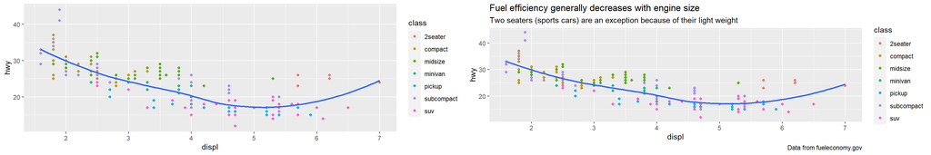

```r
gg <- ggplot(mpg, aes(displ, hwy)) + geom_point(aes(color = class)) + geom_smooth(se = FALSE)
gg1 <- gg + labs(title = "Fuel efficiency generally decreases with engine size",
                 subtitle = "Two seaters (sports cars) are an exception because of their light weight",
                 caption = "Data from fueleconomy.gov")
```

## *labs*

```r
head(mpg)
```

```
## # A tibble: 6 x 11
##   manufacturer model displ  year   cyl trans      drv     cty   hwy fl    class
##   <chr>        <chr> <dbl> <int> <int> <chr>      <chr> <int> <int> <chr> <chr>
## 1 audi         a4      1.8  1999     4 auto(l5)   f        18    29 p     compa~
## 2 audi         a4      1.8  1999     4 manual(m5) f        21    29 p     compa~
## 3 audi         a4      2    2008     4 manual(m6) f        20    31 p     compa~
## 4 audi         a4      2    2008     4 auto(av)   f        21    30 p     compa~
## 5 audi         a4      2.8  1999     6 auto(l5)   f        16    26 p     compa~
## 6 audi         a4      2.8  1999     6 manual(m5) f        18    26 p     compa~
```

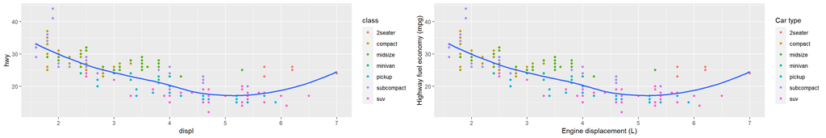

```r
gg <- ggplot(mpg, aes(displ, hwy)) + geom_point(aes(color = class)) + geom_smooth(se = FALSE)
gg1 <- gg + labs(x = "Engine displacement (L)",
                 y = "Highway fuel economy (mpg)",
                 colour = "Car type")
```

## *Facetting*

- generates small multiples, each displaying a different subset of the data.

```r
head(tips)
```

```
##   total_bill  tip    sex smoker day   time size
## 1      16.99 1.01 Female     No Sun Dinner    2
## 2      10.34 1.66   Male     No Sun Dinner    3
## 3      21.01 3.50   Male     No Sun Dinner    3
## 4      23.68 3.31   Male     No Sun Dinner    2
## 5      24.59 3.61 Female     No Sun Dinner    4
## 6      25.29 4.71   Male     No Sun Dinner    4
```

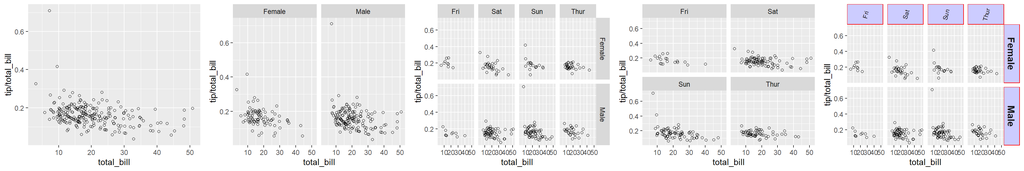

```r
sp <- ggplot(tips, aes(x=total_bill, y=tip/total_bill)) + geom_point(shape=1)
sp1 <- sp + facet_grid(. ~ sex)
sp2 <- sp + facet_grid(sex ~ day)
sp3 <- sp + facet_wrap( ~ day, ncol=2)
sp4 <- sp + facet_grid(sex ~ day) + theme(strip.text.x = element_text(size=8, angle=75),
                                          strip.text.y = element_text(size=12, face="bold"),
                                          strip.background = element_rect(colour="red", fill="#CCCCFF"))
```